# Predicting the price of Diamonds

## Phase 2: Statistical Modelling

#### Name(s) & ID(s) of Group Members: Radiyah Islam (s3866903) and Sayed Walif Ali (s3866910)

- Introduction
- Statistical Modelling
- Critique & Limitations
- Summary & Conclusions

## Introduction

### Phase 1 Summary

The purpose of our Phase 1 report was twofold - a) to clean the data and prepare it for modeling b) data visualization. Our dataset did not have any irrelevant features to drop. We renamed the columns 'x', 'y','z' and 'depth' to length, width, depth and depth percentage respectively for better readability. Next, we checked the dataset for missing values and found none. After that, we noticed that the dataset had some observations where the measurements were 0, which is physically impossible. So we proceeded to remove those observations. At this point, we considered the data clean.

The Phase 1 report used several types of graphs to visualize the data, such as scatter-plots, box diagrams and bar graphs. We saw that the color 'G' seems to be the most popular among diamonds sold. Carat and price have an exponential relationship and diamonds with SI2 clarity generally have higher prices compared to diamonds with other types of clarity. Overall, carat seems to be the most significant feature in determining the price of the diamond. Premium SI2 diamonds seem to be the most expensive type. Moreover, Ideal cut diamonds have a higher demand according to our observations. We also noticed during our data visualization that the observations for our target feature 'price' are right skewed.

The cleaned dataset from Phase 1 will be used for modeling in Phase 2 of the project. The data visualization section provided insight into which variables must be transformed for modeling.

### Report Overview

The goal of the Phase 2 report is to investigate whether we can come up with a reliable model for predicting diamond prices using the "diamonds" dataset. In this report, we will fit our dataset into a regression model and carry out multiple linear regression. We will perform dummy encoding on the categorical variables to fit them into the model. Once the model has been fitted, we verify whether the model fulfills the four conditions required for regression. Next, we carry out backward feature selection to remove any feature that is not statistically significant and then check the diagnostics of the reduced model. At the end, we analyze our model and find its limitations to figure out whether the model is appropriate to predict the price of a diamond.

### Overview of Methodology

For our project, we are using the method Multiple Linear Regression to model our data. Linear regression is one of the most commonly used methods for supervised machine learning when the dependent variable is numeric. Multiple linear regression is a statistical technique that uses several explanatory variables to predict the outcome of a response variable. It is an extension of ordinary least squares regression (OLS) because it involves more than one explanatory variable. (Hayes, 2021) Mathematically, it can be expressed as: $$ \hat{\text{y}} = \beta_0 + \beta_1 x_1 + \beta_2 x_2 + ... + \beta_k x_k $$
where,
$\hat{\text{y}}$ is the predicted value of the response variable y
$\beta_0 $ is the intercept
$ \beta_k $ is the slope
$k $ is the number of explanatory variables, and
$ x $ is the explanatory variable.

The feature we will be predicting in our report is the price of a diamond.

In order to perform regression on our dataset, we make the assumptions that our data meets the following conditions:

1. The relationship between each explanatory variable and the response variable is linear.
2. The residuals have a nearly normal distribution.
3. The observations in our dataset are independent of each other.
4. The variability of points around the least squares line is roughly constant.

After modeling our data, we will check whether our dataset meets these conditions.

To analyze our model, we will use the **adjusted** $R^2$ value. R is the correlation coefficient of the explanatory variables and the response variable. $R^2$ tells us what percent of variability in the response variable is explained by the model. We use the **adjusted** $R^2$ value, which is a ratio of explained and unexplained variability, because it can provide a more precise view of the correlation by also taking into account how many independent variables are added to a particular model. A proper model is expected to have an R-squared value of over 70%.

## Statistical Modelling

### Model Overview

The dataset being used in this report is the "diamonds" dataset sourced from the ggplot2 R library. This dataset contains information about the prices of diamonds. The features in our dataset are described in the table below.

| Name | Data Type | Units | Description |
| --- | --- | --- | --- |
| carat | Numeric | Carat | Weight of the diamond |
| cut | Ordinal categorical | NA | Quality of the cut |
| color | Ordinal categorical | NA | Color of the diamond |
| clarity | Ordinal categorical | NA | Measurement of how clear the diamond is |
| depth | Numeric | NA | Total depth percentage |
| table | Numeric | NA | Percentage for width of top of diamond relative to widest point |
| x | Numeric | mm | Length of diamond |
| y | Numeric | mm | Width of diamond |
| z | Numeric | mm | Depth of diamond |
| price | Numeric | US $ | Price of diamond |

We are going to use multiple linear regression on the dataset to predict an estimate of our response variable, `price`. Firstly, we perform one-hot-encoding (OHE) on the categorical variables. This is required as the Statsmodels module cannot do automatic variable selection on categorical variables. Then we use python to create a string for constructing the regression formula. Next, we fit an OLS (ordinary least squares) model to our encoded data. We analyze the p-values of the data and perform backward feature selection to remove statistically insignificant features. We then carry out diagnostic checks on both the full model and the reduced model to see whether they fulfill the regression assumptions. As mentioned above, we use the **adjusted** $ R^2$ value to analyze the effectiveness of the model.

#### Module Imports

```python
import numpy as np
import pandas as pd
import matplotlib.pyplot as plt
import seaborn as sns
import statsmodels.api as sm
import statsmodels.formula.api as smf
import patsy

import warnings
warnings.filterwarnings('ignore')

pd.set_option('display.max_columns', None)

%matplotlib inline
%config InlineBackend.figure_format = 'retina'
plt.style.use("ggplot")

df = pd.read_csv('cleaned_diamonds.csv')
```

### Model Fitting

We begin by fitting a multiple linear regression that predicts the price of diamonds using all of the available features. We call this the full model. First let's take a quick peak at the clean data.

```python
df.head()
```

|  | carat | cut | color | clarity | depth_percentage | table | length | width | depth | price |
| --- | --- | --- | --- | --- | --- | --- | --- | --- | --- | --- |
| 0 | 1.10 | Premium | H | SI2 | 62.2 | 58.0 | 6.69 | 6.60 | 4.13 | 4620 |
| 1 | 1.51 | Very Good | J | SI2 | 63.2 | 58.0 | 7.28 | 7.25 | 4.59 | 6171 |
| 2 | 0.72 | Ideal | D | VS2 | 61.8 | 56.0 | 5.74 | 5.78 | 3.56 | 4082 |
| 3 | 1.04 | Premium | E | SI2 | 61.6 | 59.0 | 6.55 | 6.57 | 4.04 | 4164 |
| 4 | 0.80 | Premium | G | SI1 | 63.0 | 59.0 | 5.90 | 5.81 | 3.69 | 2760 |

In Phase 1, we observed that our target variable 'price' was right skewed. As a result, we perform log transformation on the variable for better modeling.

```python
df['price']=np.log(df['price'])
```

```python
df_encoded = pd.get_dummies(df)
df_encoded = df.rename(columns={'cut_Very Good': 'cut_Very_Good'})
df_encoded.head()
```

|  | carat | cut | color | clarity | depth_percentage | table | length | width | depth | price |
| --- | --- | --- | --- | --- | --- | --- | --- | --- | --- | --- |
| 0 | 1.10 | Premium | H | SI2 | 62.2 | 58.0 | 6.69 | 6.60 | 4.13 | 8.438150 |
| 1 | 1.51 | Very Good | J | SI2 | 63.2 | 58.0 | 7.28 | 7.25 | 4.59 | 8.727616 |
| 2 | 0.72 | Ideal | D | VS2 | 61.8 | 56.0 | 5.74 | 5.78 | 3.56 | 8.314342 |
| 3 | 1.04 | Premium | E | SI2 | 61.6 | 59.0 | 6.55 | 6.57 | 4.04 | 8.334231 |
| 4 | 0.80 | Premium | G | SI1 | 63.0 | 59.0 | 5.90 | 5.81 | 3.69 | 7.922986 |

```python
formula_string_indep_vars_encoded = ' + '.join(df_encoded.drop(columns='price').columns)
formula_string_encoded = 'price ~ ' + formula_string_indep_vars_encoded
print('formula_string_encoded: ', formula_string_encoded)
```

```
formula_string_encoded:  price ~ carat + cut + color + clarity + depth_percentage + table + length + width + depth
```

Now that we have defined our statistical model formula as a Python string, we fit an OLS (ordinary least squares) model to our encoded data.

```python
full_model = sm.formula.ols(formula=formula_string_encoded, data=df_encoded)

full_model_fitted = full_model.fit()

print(full_model_fitted.summary())
```

```
                            OLS Regression Results
==============================================================================
Dep. Variable:                  price   R-squared:                       0.983
Model:                            OLS   Adj. R-squared:                  0.983
Method:                 Least Squares   F-statistic:                 1.243e+04
Date:                Thu, 24 Mar 2022   Prob (F-statistic):               0.00
Time:                        00:42:50   Log-Likelihood:                 2985.0
No. Observations:                5000   AIC:                            -5922.
Df Residuals:                    4976   BIC:                            -5766.
Df Model:                          23
Covariance Type:            nonrobust
====================================================================================
                       coef    std err          t      P>|t|      [0.025      0.975]
------------------------------------------------------------------------------------
Intercept            0.4963      0.375      1.325      0.185      -0.238       1.231
cut[T.Good]          0.0860      0.012      6.907      0.000       0.062       0.110
cut[T.Ideal]         0.1403      0.012     11.437      0.000       0.116       0.164
cut[T.Premium]       0.1093      0.012      9.289      0.000       0.086       0.132
cut[T.Very Good]     0.0966      0.012      8.103      0.000       0.073       0.120
color[T.E]          -0.0512      0.007     -7.306      0.000      -0.065      -0.037
color[T.F]          -0.0935      0.007    -13.254      0.000      -0.107      -0.080
color[T.G]          -0.1575      0.007    -22.766      0.000      -0.171      -0.144
color[T.H]          -0.2462      0.007    -33.745      0.000      -0.260      -0.232
color[T.I]          -0.3712      0.008    -45.172      0.000      -0.387      -0.355
color[T.J]          -0.5151      0.010    -50.326      0.000      -0.535      -0.495
clarity[T.IF]        1.0882      0.020     53.333      0.000       1.048       1.128
clarity[T.SI1]       0.5755      0.017     32.982      0.000       0.541       0.610
clarity[T.SI2]       0.4128      0.018     23.572      0.000       0.378       0.447
clarity[T.VS1]       0.7979      0.018     44.753      0.000       0.763       0.833
clarity[T.VS2]       0.7321      0.018     41.752      0.000       0.698       0.766
clarity[T.VVS1]      0.9909      0.019     52.840      0.000       0.954       1.028
clarity[T.VVS2]      0.9366      0.018     51.098      0.000       0.901       0.972
carat               -1.0447      0.019    -53.906      0.000      -1.083      -1.007
depth_percentage    -0.0193      0.006     -3.323      0.001      -0.031      -0.008
table                0.0102      0.001      8.860      0.000       0.008       0.012
length               0.6391      0.052     12.261      0.000       0.537       0.741
width               -0.0852      0.007    -12.762      0.000      -0.098      -0.072
depth                1.3876      0.095     14.654      0.000       1.202       1.573
==============================================================================
Omnibus:                      198.876   Durbin-Watson:                   2.065
Prob(Omnibus):                  0.000   Jarque-Bera (JB):              613.872
Skew:                          -0.056   Prob(JB):                    5.00e-134
Kurtosis:                       4.713   Cond. No.                     1.74e+04
==============================================================================

Notes:
[1] Standard Errors assume that the covariance matrix of the errors is correctly specified.
[2] The condition number is large, 1.74e+04. This might indicate that there are
strong multicollinearity or other numerical problems.
```

```python
residuals_full = pd.DataFrame({'actual': df_encoded['price'],
                            'predicted': full_model_fitted.fittedvalues,
                            'residual': full_model_fitted.resid})
residuals_full.head(10)
```

|  | actual | predicted | residual |
| --- | --- | --- | --- |
| 0 | 8.438150 | 8.457317 | -0.019167 |
| 1 | 8.727616 | 8.688029 | 0.039588 |
| 2 | 8.314342 | 8.109921 | 0.204422 |
| 3 | 8.334231 | 8.524993 | -0.190762 |
| 4 | 7.922986 | 7.968671 | -0.045685 |
| 5 | 6.742881 | 6.589308 | 0.153572 |
| 6 | 9.284241 | 9.370655 | -0.086413 |
| 7 | 9.414179 | 9.352294 | 0.061885 |
| 8 | 8.934455 | 8.772409 | 0.162046 |
| 9 | 8.374015 | 8.368865 | 0.005151 |

Let's plot actual price values vs. predicted price values.

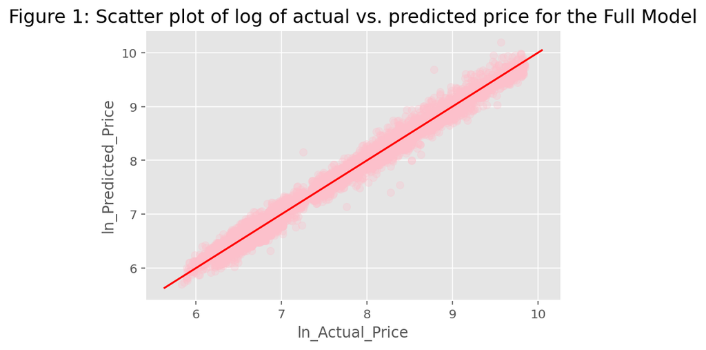

```python
def plot_line(axis, slope, intercept, **kargs):
    xmin, xmax = axis.get_xlim()
    plt.plot([xmin, xmax], [xmin*slope+intercept, xmax*slope+intercept], **kargs)

# Creating scatter plot
plt.scatter(residuals_full['actual'], residuals_full['predicted'], alpha=0.3, c='pink');
plot_line(axis=plt.gca(), slope=1, intercept=0, c="red");
plt.xlabel('ln_Actual_Price');
plt.ylabel('ln_Predicted_Price');
plt.title('Figure 1: Scatter plot of log of actual vs. predicted price for the Full Model', fontsize=15);
plt.show();
```

From Figure 1, we see that most of the points are clustered around the OLS regression line. This means that there is a strong positive correlation between actual and predicted price. The residuals are quite low, with the exception of a few outliers. This suggests that our model is mostly a good predictor for the price of a diamond.

We will now check the diagnostics for the full model.

### Full Model Diagnostic Checks

We would like to check whether there are indications of violations of the regression assumptions, which are

1. linearity of the relationship between target variable and the independent variables
2. constant variance of the errors
3. normality of the residual distribution
4. statistical independence of the residuals

Let's first get a scatter plot of residuals (as a function of predicted `price`).

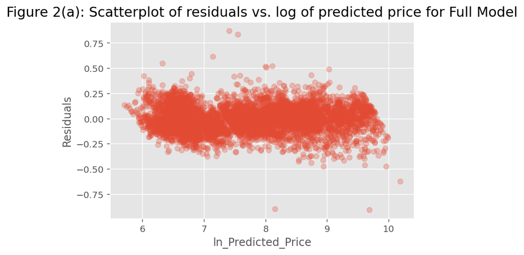

```python
plt.scatter(residuals_full['predicted'], residuals_full['residual'], alpha=0.3);
plt.xlabel('ln_Predicted_Price');
plt.ylabel('Residuals')
plt.title('Figure 2(a): Scatterplot of residuals vs. log of predicted price for Full Model', fontsize=15)
plt.show();
```

From Figure 2(a), we see that the residuals are mostly random and centered around 0, although not completely. There are few outliers which has very low predicted price but the value of residuals is quite high. Our graph is quite consistent for higher ln_predicted_price. This pattern indicates that the constant variability assumption of linear regression is mostly satisfied in this case.

Let's now plot actual price vs. residuals.

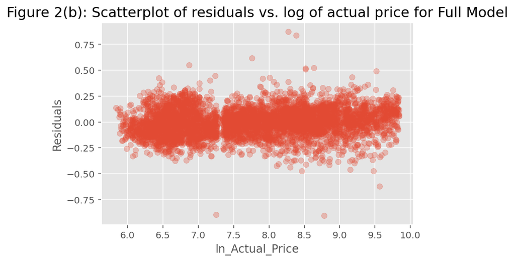

```python
plt.scatter(residuals_full['actual'], residuals_full['residual'], alpha=0.3);
plt.xlabel('ln_Actual_Price');
plt.ylabel('Residuals')
plt.title('Figure 2(b): Scatterplot of residuals vs. log of actual price for Full Model', fontsize=15)
plt.show();
```

From Figure 2(b), we see that most of the residuals are centered around 0. However, there are a few outliers with high residuals for ln_Actual_Price greater than 7.5.

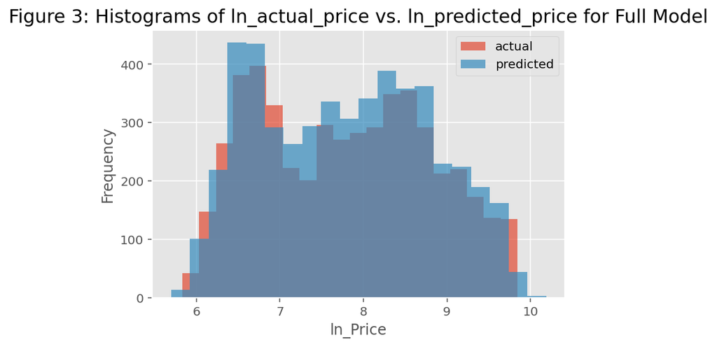

```python
plt.hist(residuals_full['actual'], label='actual', bins=20, alpha=0.7);
plt.hist(residuals_full['predicted'], label='predicted', bins=20, alpha=0.7);
plt.xlabel('ln_Price');
plt.ylabel('Frequency');
plt.title('Figure 3: Histograms of ln_actual_price vs. ln_predicted_price for Full Model', fontsize=15);
plt.legend()
plt.show();
```

Let's now have look at the histogram of the residuals.

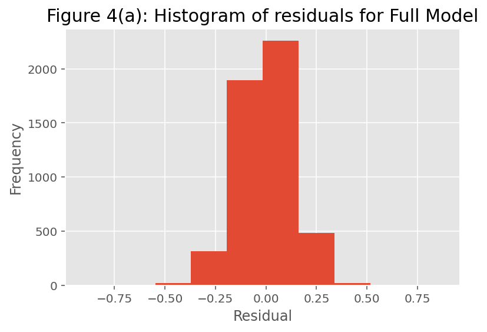

```python
plt.hist(residuals_full['residual'], bins = 10);
plt.xlabel('Residual');
plt.ylabel('Frequency');
plt.title('Figure 4(a): Histogram of residuals for Full Model', fontsize=15);
plt.show();
```

Now we check whether the residuals have a normal distribution if we remove the outliers of the residuals.

```python
q1 = residuals_full['residual'].quantile(0.25)
q3 = residuals_full['residual'].quantile(0.75)

IQR = q3-q1
lower = q1 - 1.5 * IQR
upper = q3 + 1.5 * IQR

for res in residuals_full['residual']:
    if (res < lower) | (res > upper):
        residuals_full['residual'] = residuals_full[['residual']].replace(res,np.NaN)
        residuals_full.dropna(inplace=True)
```

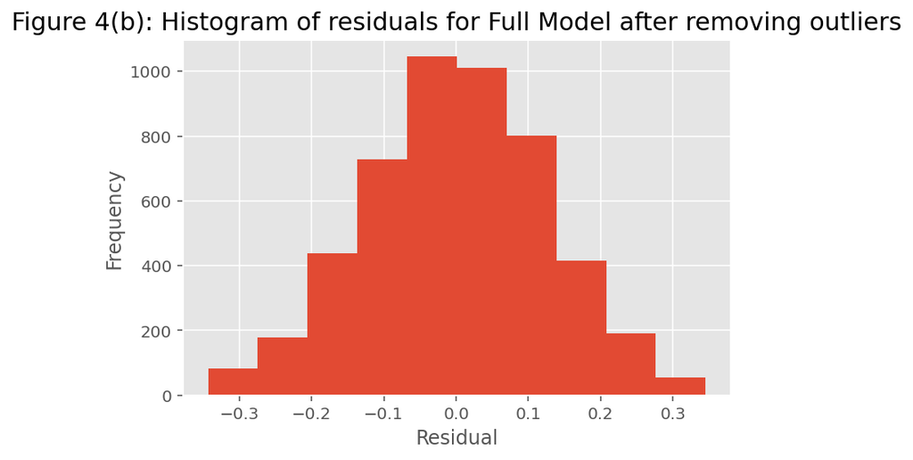

```python
plt.hist(residuals_full['residual'], bins = 10);
plt.xlabel('Residual');
plt.ylabel('Frequency');
plt.title('Figure 4(b): Histogram of residuals for Full Model after removing outliers', fontsize=15);
plt.show();
```

From Figure 4(b), we see that the histogram is symmetric and centered at 0. This tells us that if we remove the outliers from the residuals, the model fulfills the normality assumption of linear regression.

### Feature Selection

In the summary table of our full model above, we can see that the `P > |t|` column does not have any value that is greater than 0.05. So we can conclude that all our features are statistically significant. Hence, we do not have to carry out backward selection to remove insignificant features. Since we do not have any features to remove, we won't have a reduced model.

## Critique & Limitations

The prominent flaw in our model are the outliers present in the data. With outliers present in the data, the normality assumption of linear regression is violated. This suggests that our model cannot accurately predict extreme values, such as diamonds that are extremely expensive or diamonds that have very low prices. If we were to include the outliers in the data, it might be the case that nonlinear models such as a neural network might be more appropriate for the task at hand rather than a linear regression model.

## Summary & Conclusions

### Project Summary

In Phase 1 of the project, we took on the tasks of data cleaning, preprocessing and data visualization. We checked whether all the columns were relevant to our goal, which they were. We renamed some of the columns as mentioned in the introduction. Then we checked whether the data types of the variables matched the intended data types. The dataset did not have any errors in this regard. After that, we checked the unique values for the categorical variables to ensure they did not have variations of the same value. Next, we noticed from the summary table of the numerical values that the minimum length, width and depth were 0. These values are invalid so we cleaned the dataset by removing those observations. We chose not to remove the outliers from the features as the values fall within a valid range. Afterwards, we plotted some graphs to visualize the data and better understand the relationships between the variables.

### Conclusions

Since our adjusted R-squared value is above 90%, we can conclude that our model is a very good predictor of the price of a diamond. All of our features are highly relevant. Due to the high explained variability of the model, it can be used in the real-world by diamond retailers. Potential customers can use the model individually to figure out the ideal cut, clarity, and size of a diamond within their budget. In conclusion, the model can be considered valid and useful.

## References

- Hayes, A. (2021). Multiple Linear Regression (MLR) Definition. Retrieved 20 October 2021, from https://www.investopedia.com/terms/m/mlr.asp
- ggplot2/data.R at master · tidyverse/ggplot2. (2021). Retrieved 1 October 2021, from https://github.com/tidyverse/ggplot2/blob/master/R/data.R
- stats_tutorials/Regression_Case_Study1_web.ipynb at master · vaksakalli/stats_tutorials. (2021). Retrieved 24 October 2021, from https://github.com/vaksakalli/stats_tutorials/blob/master/Regression_Case_Study1_web.ipynb